# Practical ML - Linear Regression with Gradient Descent

### Simple Linear Regression Gradient Descent

In the previous notebook, we looked at simple linear regression and provide a closed form solution for estimating the coefficients/parameters for our model. In this module, let's work on a different parameter estimation technique called **Gradient Descent**. Gradient descent is a powerful algorithm that is used in a variety of modeling techniques.

#### Recall the linear model

Note that we are trying to estimate $\beta_0$ and $\beta_1$. We do this by defining our cost function and making it our objective to minimize that cost function.

#### Recall the Cost Function

Our cost function can be mathematically represented as:

$$ RSS = \sum_{n=i}^{N} ({y_i - \widehat{y_i}})^2$$

Note that the above formula can be written as: $$ \sum_{n=i}^{N} (y_i - (\widehat{\beta_0} + \widehat{\beta_1}*x))^2 = \sum_{n=i}^{N} (\epsilon_i)^2$$

### Conceptual Gradient Descent

In the closed form solution, we derived the parameters each at a time by computing the partial derivative of the cost function for $\beta_0$ and $\beta_1$ individually. In many cases, computers often use matrix methods to compute this estimation. In fact, the notation for the closed form solution in matrix notation is:

$$ \beta = (H^TH)^{-1}H^Ty$$

where:  
$\beta: vector\ of\ all\ coefficients$  
$H: input\ matrix\ (matrix of\ our\ input\ variables)$  
$y: vector\ of\ our\ predicted\ variable$

Inverting a matrix can be computationally prohibitive, therefore, gradient descent is a much better option. To set up the gradient descent, we need to set up the following dependencies:

1. Initialize a vector of our parameters $\beta$. We can initialize parameters to Zero  
2. Step Size need for parameter approximation. We can set this as a decaying value  
3. Partial derivative for every parameter we are trying to estimate.  
The generic partial derivative formular is:

$$\frac {\partial RSS(\beta)}{\beta_i} = -2\sum x_i (y_i - \widehat y(\beta))$$

4. Updating the parameter:

$$\beta_i^{t+1} = \beta_i^{t} - t * \frac {\partial RSS(\beta)}{\beta_i} $$ where:
$t: stepsize$

5. Convergence criteria. $$\| \nabla RSS(\beta^{t}) \| > \epsilon$$

where:  
$\epsilon: is\ a\ predefined\ torelance$

#### Summarizing the Algorithm

$$while\ \| \nabla RSS(\beta^{t}) \| > \epsilon: $$ $$ for\ i = 0,1,...,D$$
$$\frac {\partial RSS(\beta)}{\beta_i} = -2\sum x_i (y_i - \widehat y(\beta))$$
$$\beta_i^{t+1} = \beta_i^{t} - t * \frac {\partial RSS(\beta)}{\beta_i}$$

Now, let's implement this in python

```python
import numpy as np
import pandas as pd
import matplotlib.pyplot as plt

%matplotlib inline
%config InlineBackend.figure_format = 'retina'
```

#### Setting up some data.

Below we set up some dummy data.

```python
x = np.array([0., 1., 2., 3., 4., 5., 6., 7.])
y = np.array([-.82, -.94, -.12, .26, .36, .64, 1.02, 1.])

data = pd.DataFrame(list(zip(x,y)), columns=['x', 'y'])
data.head()
```

|  | x | y |
| --- | --- | --- |
| 0 | 0.0 | -0.82 |
| 1 | 1.0 | -0.94 |
| 2 | 2.0 | -0.12 |
| 3 | 3.0 | 0.26 |
| 4 | 4.0 | 0.36 |

### Visualizing the data

Let's visualize the dataset we create above to understand the relationships if any.

```
Text(0,0.5,'target variable')
```

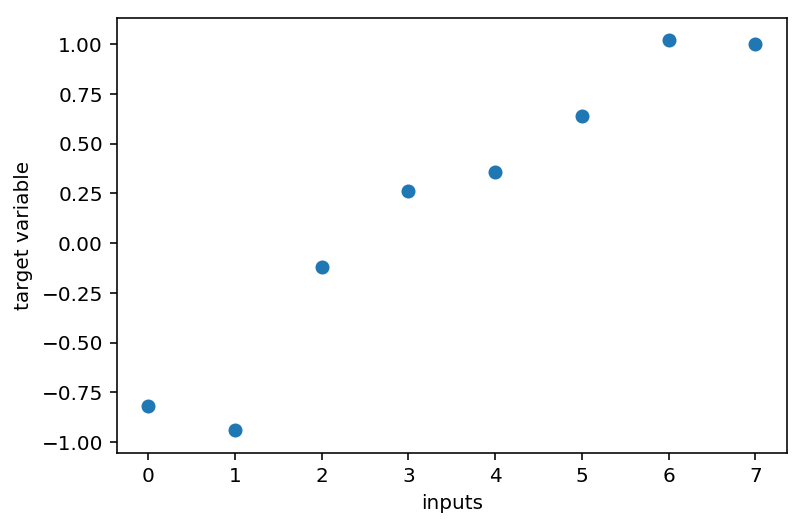

```python
plt.scatter(data.x, data.y)
plt.xlabel('inputs'); plt.ylabel('target variable')
```

### Gradient Descent Function

Now we write the gradient descent function

```python
def gradient_descent(initial_weights, inputs, target, datafile, learning_rate, tolerance):

    # Initialize the constance feature
    datafile['constant'] = 1
    features = ['constant'] + inputs
    feature_matrix = datafile[features].as_matrix()

    target_variable = datafile[target]

    # Initialize Weights
    weights = initial_weights

    # Counting Iterations
    count = 0

    converged = False
    while not converged:

        predictions = np.dot(feature_matrix, weights)
        errors = target_variable - predictions

        gradient_sum_squares = 0
        for i in range(len(weights)):

            derivative = np.dot(errors, feature_matrix[:, i])
            weights[i] = weights[i] + (2*learning_rate*derivative)

            gradient_sum_squares += derivative**2

        # Computing the tolerance
        gradient_sum_squares = np.sqrt(gradient_sum_squares)


        if gradient_sum_squares < tolerance:
            converged = True


    return weights
```

```python
final_weights = gradient_descent([0.0,0.0], ['x'], 'y', data, .001, 0.0001)
print(final_weights)
```

```
[-0.8632911475929222, 0.2966580882064248]
```

### Plotting the Regression Line

Now let's plot our predicted line

```
Text(0,0.5,'target variable')
```

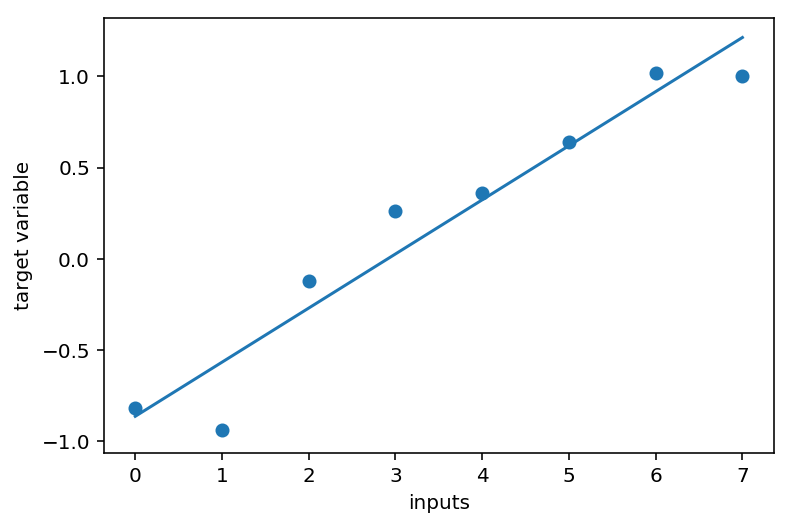

```python
data['predict'] = final_weights[0] + final_weights[1]*data['x']


plt.scatter(data['x'], data['y'])
plt.plot(data['x'], data['predict'])
plt.xlabel('inputs'); plt.ylabel('target variable')
```

### Sklearn Solution

Now let's use the sklearn solution to determine the result.

```python
from sklearn import linear_model
```

#### Initializing the Model

Now, let's initiatlize the model

```python
model = linear_model.LinearRegression(fit_intercept=True)
model.fit(data[['x']], data['y'])
```

```
LinearRegression(copy_X=True, fit_intercept=True, n_jobs=1, normalize=False)
```

#### Model Coefficients

Now we can look at returning the model coefficients from sklearn. Notice the result is equivalent to our closed form solution.

```python
print(model.coef_[0], model.intercept_)
```

```
0.2966666666666667 -0.8633333333333333
```

This concludes our session on gradient descent.